# Stimuli mixed DPs, frequencies

# Overview

The items selected for each condition should have a similar overall frequency. Here we check the frequency of the words for the two main predictors (i.e. conditions): analogical gender, phonological ending.

We have available frequencies from four corpora (in decreasing size):

- ETC: 269.2 M words
- EHME: 22.7 M words
- ehitz: 3.5 M words
- ahotsak: 2.7 M words

However, the last two (ehitz, ahotsak) are too small to provide reliable measures. Brysbaert et al. (2011) argue: “Word frequency measures should be based on a corpus of at least 20 million words.” All frequencies are log-normalised (base=10), and Laplace (additive) smoothing has been applied (Brysbaert et al. 2013).

|  | lemma | eu.ending | es.gender | ehme_log | etc_log | ehitz_log | ahotsak_log |
| --- | --- | --- | --- | --- | --- | --- | --- |
| 1 | gona | a | f | 1.41 | 1.06 | 1.45 | 1.74 |
| 2 | tanta | a | f | 1.6 | 1.48 | 1.1 | 1.22 |
| 3 | soka | a | f | 1.83 | 1.23 | 1.9 | 2.07 |
| 4 | tipula | a | f | 0.88 | 0.84 | 1.01 | 1.11 |
| 5 | gazta | a | m | 1.41 | 1.48 | 1.63 | 2.1 |
| 6 | galtza | a | m | 2.22 | 1.22 | 1.58 | 1.87 |
| 7 | uda | a | m | 2.29 | 2.27 | 2.25 | 2.29 |
| 8 | errota | a | m | 1.34 | 1.3 | 1.61 | 2.49 |
| 9 | leiho | o | f | 2.35 | 2 | 2.34 | 1.31 |
| 10 | hosto | o | f | 1.68 | 1.59 | 2.04 | 1.23 |

[output cut: 22 more lines]

# Stimuli frequencies in context

The words in the stimuli are more frequent than 87% (according to EHME) or 85% (according to ETC) of the nouns in Basque (that is, they are within the top ~15% most frequent nouns). The plots below show the frequency of the stimuli items against the frequency distribution of all Basque nouns. The vertical line indicates the 3rd quartile in each corpus; all the stimuli are within the top quartile of the noun distribution in both corpora. In each plot, the upper set of words are those with a masc analogical gender, and the lower set are those with a fem analogical gender.

## Stimuli frequencies against all nouns in EHME

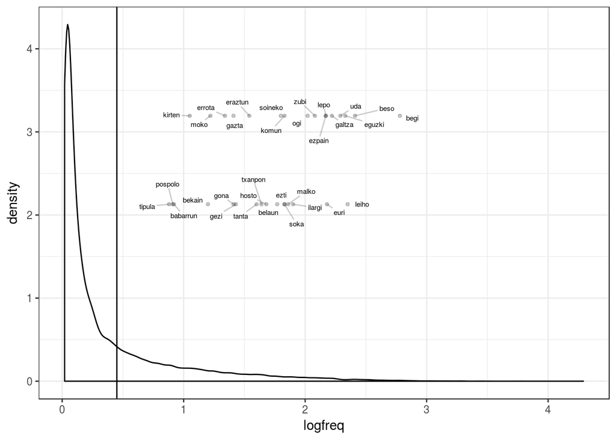

## Stimuli frequencies against all nouns in ETC

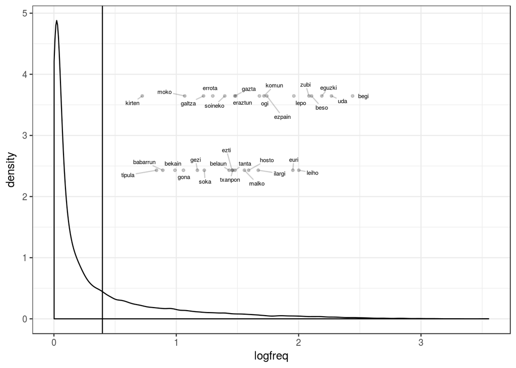

# Frequencies by condition (Zipf)

We can further assess the mean frequencies for each experimental condition. The main predictors are es.gender (f, m) and eu.ending (a, o, i, n), which give a total of 8 conditions. Following van Heuven et al. (2014) we use the Zipf-scale as a thumb rule for high vs low frequencies. The Zipf-scale is similar to the log10 transformation but yields a 7-point scale. They consider Zipf-values higher than 4 ‘high-frequency’ words. All 8 conditions show a mean frequency above this threshold (>4) for both corpora (EHME, ETC).

| eu.ending | es.gender | zipf_ehme | zipf_etc |
| --- | --- | --- | --- |
| a | f | 4.43 | 4.15 |
| a | m | 4.81 | 4.57 |
| i | f | 4.84 | 4.56 |
| i | m | 5.30 | 5.10 |
| n | f | 4.38 | 4.19 |
| n | m | 4.65 | 4.42 |
| o | f | 4.70 | 4.72 |
| o | m | 4.90 | 4.63 |

Even if the mean frequency for each condition is relatively high, there might be systematic differences across conditions.

Below, we explore (visually) and analyse (statistically) the frequency distribution for the different conditions. The position of the words in the plots is approximate (in order to avoid overlap).

# Frequencies by condition (plots)

## Frequencies by analogical gender (f, m).

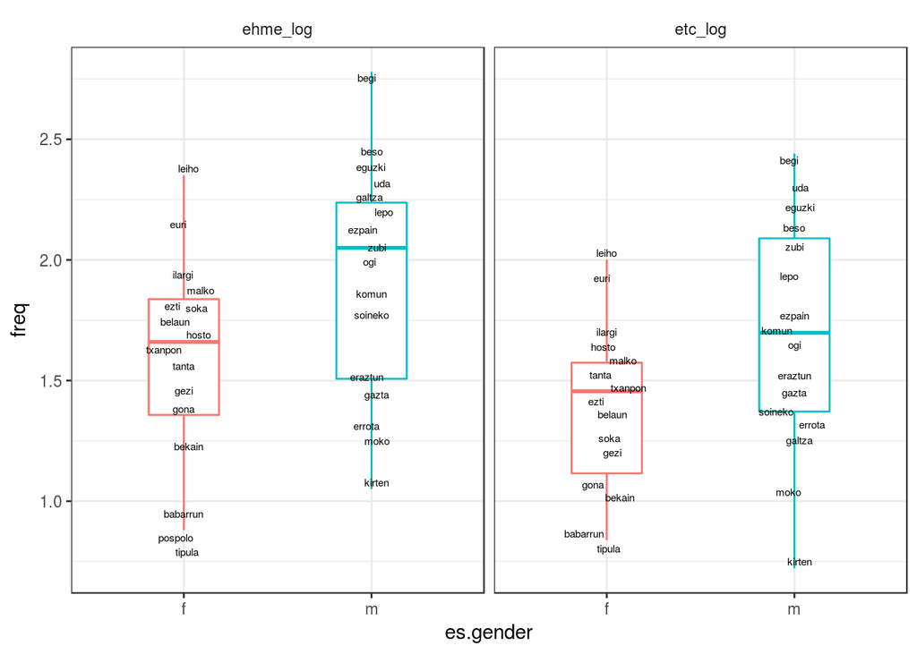

## Frequencies by phonological ending (a, i, n, o).

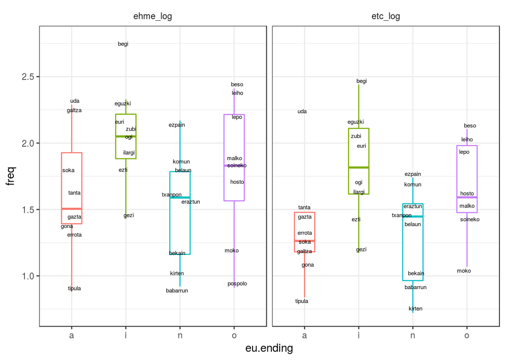

## Frequencies by gender-prototypical ending (a, o).

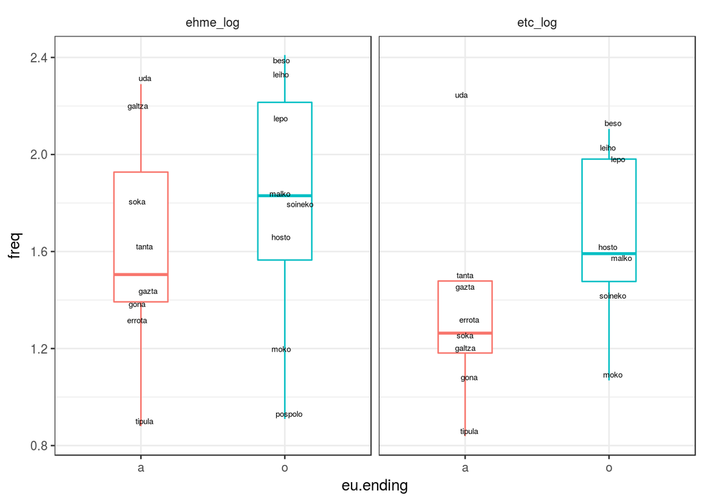

# Statistical tests

Follow-up on the tendencies shown by the plots using t-tests. Compare the frequencies in the two analogical-gender conditions: f vs m. In both corpora, words with es.gender=f are less frequent than es.gender=m. However, the difference is *not* statistically significant (p>.05).

| corpus | t.value | estimate | p.value |
| --- | --- | --- | --- |
| ehme_log | -2.013275 | -0.3293750 | 0.0532327 |
| etc_log | -1.950262 | -0.2931659 | 0.0613736 |

Compare the frequencies for the two gender-prototypical endings: a vs o. Both EHME and ETC show a slightly lower frequency for the -a ending (prototypically fem) vs the -o ending (prototypically masc). Not statistically significant either.

| corpus | t.value | estimate | p.value |
| --- | --- | --- | --- |
| ehme_log | -0.7074226 | -0.1775000 | 0.4910534 |
| etc_log | -1.5027308 | -0.3094939 | 0.1568151 |

A one-way analysis of the frequencies of the 8 conditions reveals that their means are not significantly different.

| corpus | F.value | p.value |
| --- | --- | --- |
| ehme_log | 1.743798 | 0.2028228 |
| etc_log | 2.832729 | 0.0683167 |